# Développement web dlm3

## HTTP & AJAX

# HyperText Transfer Protocol

- Protocole application : invention www en 1990 (v0.9)
  - Connexion, GET, réponse, fermeture
- HTTP 1.0 (1996)
  - Entêtes de requête (Host, Referer, User-Agent, …) et réponse (Content-Type, Set-Cookie, Location, …)
- HTTP 1.1 (1997)
  - Nouveaux entêtes (Keep-alive, pipelining, cache, …), Host obligatoire
- [HTTP 2.0](https://docs.google.com/presentation/d/1eqae3OBCxwWswOsaWMAWRpqnmrVVrAfPQclfSqPkXrA/present#slide=id.p19) (2015)
  - Binaire, multiplexage connexions, compression entêtes, push, …
  - Supporté par [presque tous](http://caniuse.com/#feat=http2) les navigateurs, une majorité de serveurs
- [HTTP 3.0](https://http3-explained.haxx.se/fr/) (2019)
  - UDP, correction erreur, contrôle congestion, multiplexage (0 RTT)

# Codes de réponse

- 1xx : Information
- 2xx : Succès
- 3xx : Redirection
- 4xx : Erreur Client
- 5xx : Erreur Serveur

# Méthodes HTTP (verbes)

- GET : Demander une ressource
- POST : Création d’une ressource
- PUT : Remplacement total d’une ressource
- PATCH : Remplacement partiel d’une ressource
- DELETE : Suppression d’une ressource
- HEAD : Demande l’entête de la réponse, sans la ressource
- TRACE, OPTIONS, CONNECT

idempotentes  
sûres

# Echanges HTTP

- Requête

```html
GET / HTTP/1.1[CRLF]
Host: www.cff.ch[CRLF]
Connection: close[CRLF]
User-Agent: Opera/9.20 (Windows NT 6.0; U; en)[CRLF]
Accept-Encoding: gzip[CRLF]
Accept-Charset: ISO-8859-1,UTF-8;q=0.7,*;q=0.7[CRLF]
Cache-Control: no[CRLF]
Accept-Language: de,en;q=0.7,en-us;q=0.3[CRLF]
Referer: http://web-sniffer.net/[CRLF]
[CRLF]
```

- Réponse

```html
HTTP Status Code:   HTTP/1.1 302 Found
Date:           Mon, 16 Nov 2009 08:01:35 GMT
Server:         Apache
Location:       http://www.sbb.ch/fr/
Content-Length:     205
Connection:     close
Content-Type:       text/html; charset=iso-8859-1

<!DOCTYPE HTML PUBLIC "-//IETF//DTD HTML 2.0//EN">
<html><head><title>302 Found</title>
</head><body>
<h1>Found</h1>
<p>The document has moved <a href="http://www.sbb.ch/fr/">here</a>.</p>
</body></html>
```

# HTTP

- Requête POST : paramètres dans le corps

```html
POST /login.jsp HTTP/1.1
Host: www.mysite.com
User-Agent: Mozilla/4.0
Content-Length: 27
Content-Type: application/x-www-form-urlencoded

userid=joe&password=guessme
```

- Outils HTTP
  - CLI : curl
  - Browser dev tools
- Exemples PATCH : [mnot](http://www.mnot.net/blog/2012/09/05/patch) , [SOA bits](http://soabits.blogspot.ch/2013/01/http-put-patch-or-post-partial-updates.html)

# AJAX : Historique

- Asynchronous Javascript And Xml
- Buzzword, [Jesse James Garret](http://web.archive.org/web/20110102130434/http://www.adaptivepath.com/ideas/essays/archives/000385.php), 2005
- Mise à jour sans rechargement intégral
- Utilisation de [Remote Scripting](https://en.wikipedia.org/wiki/Remote_scripting) et de DOM
- Historique de techniques de remote scripting
  - (i)frames
  - Bibliothèques JS (ex: [JSRS](http://www.ashleyit.com/rs/jsrs/test.htm))
  - Utilisation des images/cookies (ex: [GIF](http://web.archive.org/web/20100916110710/http://depressedpress.com/Content/Development/JavaScript/Articles/GIFAsPipe/Index.cfm))
  - Applets, Flash, ActiveX, …
  - XHR : XML HTTP Request (IE5, 1999 pour OWA)
  - Fetch API
- Pas obligatoire d’avoir du JS, XML ni d’être asynchrone !

# AJAX

- XHR est devenue la méthode standard jusqu’à 2018
  - Popularisée par Google (GMaps, GMail, …)
  - Le w3c fait évoluer un [draft](https://www.w3.org/TR/XMLHttpRequest/) depuis 2006
- Principe
  1. Envoi de requête HTTP
  2. La réponse provoque l’éxecution de la fonction de rappel
  3. Le DOM de la page est mis à jour
- Applications
  - GUI ressemblant à des app natives
  - MAJ dynamiques de formulaires, autocompletion
  - Validation avec interrogation du serveur
  - …

# L’objet *XMLHttpRequest*

- Initiative de Microsoft
  - Composant ActiveX de IE5
  - Adopté par Mozilla 1.0 et Safari 1.2
  - Standardisation W3C en cours
- Requête HTTP en JS
- Fonction de rappel (callback)
- Asynchrone : Non bloquant
- Non standard => différentes implémentations
- Supporté par la majorité des navigateurs
- Alternative souhaitable si JS désactivé

# XHR en JS

```javascript
var xhr;
function createXMLHttpRequest()
{
    if (window.ActiveXObject)
    {
        xhr = new ActiveXObject("Microsoft.XMLHTTP");
    }
    else if (window.XMLHttpRequest)
    {
        xhr = new XMLHttpRequest();
    }
}
```

- Dans son [contexte](http://www.xul.fr/xml-ajax.html#ajax-exemple)

# XHR en jQuery avec *load()*

```html
<!DOCTYPE html>
<html>
<head>
<script src="jquery.js"></script>
<script>
$(document).ready(function(){
  $("button").click(function(){
    $("#div1").load("demo_test.txt");
  });
});
</script>
</head>

<body>
  <div id="div1"><h2>Let jQuery AJAX Change This Text</h2></div>
  <button>Get External Content</button>
</body>
</html>
```

- [Tester](http://www.w3schools.com/jquery/tryit.asp?filename=tryjquery_ajax_load)
- D’[autres](https://code.tutsplus.com/tutorials/jquery-succinctly-jquery-and-ajax--net-33856) façons de faire

# XHR : propriétés et méthodes

- `readyState, status, onreadystatechange`
- `responseText, responseXML`
- `open (Verbe, URI, async) :`
  - `Verbe` HTTP : “GET”, “POST” ou “PUT”
  - `URI` : destinataire de la requête
  - `async` (bool) : `true` = asynchrone, `false` = bloquant
- `send (null | string)` : peut être bloquante
- `setRequestHeader(header, value)`
- `getResponseHeader(string)`
- `abort()`

# Envoi de données

- GET
  - Obtenir des données
  - Longueur URL limitée par le navigateur (2’048 pour IE)
  - Utilise le cache (navigateur, proxy)
  - manipulables par l’utilisateur (bookmarks, partage, …)
- POST
  - Faire quelque chose
  - Données sensibles
  - Longueur limitée par le serveur (assez large)
  - Utilisation de la méthode send() de XHR
  - Requête Ajax en 2 temps (entête, puis données)

# Envoi de données

- Cache
  - Client : Construire des [URL uniques](http://stackoverflow.com/questions/367786/prevent-browser-caching-of-jquery-ajax-call-result)
  - Serveur : Envoi d’[entêtes](https://developers.google.com/web/fundamentals/performance/optimizing-content-efficiency/http-caching) interdisant le cache

```javascript
MyXhr.open("GET", "fichier.xml", true);
MyXhr.setRequestHeader("Cache-Control", "no-store, no-cache, must-revalidate,
            post-check=0, pre-check=0");
MyXhr.setRequestHeader("Pragma", "no-cache");
MyXhr.setRequestHeader("Expires", "Wed, 09 Aug 2000 08:21:57 GMT");
```

# Préférer GET, sauf

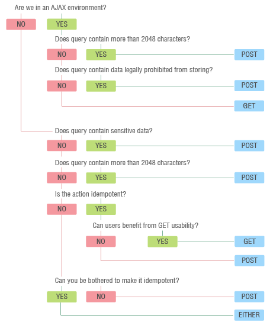

“GETorPOST”

[Détails](http://blog.teamtreehouse.com/the-definitive-guide-to-get-vs-post)

# Réponse en texte

- Si la requête aboutit :
  - `readystate == 4`
  - `status == 200`
- La réponse est dans l’attribut `responseText`
- ou dans `responseXML`
  - Utilisation du DOM (`getElementsByTagName(), ...`)

# Réponse en XML

```xml
<?xml version="1.0" ?>
<liste>
     <personne>
         <nom>Berger</nom>
         <prenom>Laurent</prenom>
     </personne>
     <personne>
         <nom>Borgo</nom>
         <prenom>Sébastien</prenom>
     </personne>
     <personne>
         <nom>Bux</nom>
         <prenom>Rémy</prenom>
     </personne>
</liste>
```

- Dans `responseXML`

# Réponse en [JSON](http://www.json.org/)

- [Standard](http://www.ecma-international.org/publications/files/ECMA-ST/ECMA-404.pdf) depuis octobre 2013 ([Douglas Crockford](http://www.crockford.com/))
- Tableau d’objets js :
  - pour chacun, ses attributs sont des paires clé:valeur

```json
{"nom": "Berger", "prénom": "Laurent"}
```

```json
["zéro", 1, 2, 3]
```

```json
[
  {"nom": "Berger", "prénom": "Laurent"},
  {"nom": "Borgo",  "prénom": "Sébastien"},
  {"nom": "Bux",    "prénom": "Rémy"}
]
```

- Utilisation de : var users = eval(‘(’ + myXHR.responseText + ‘)’); pour créer le tableau d’objets correspondant

# [« eval is Evil »](https://javascriptweblog.wordpress.com/2010/04/19/how-evil-is-eval/)

- `eval()` : évalue et exécute la chaîne en paramètre
- Risque : instructions au lieu d’un tableau d’objets
- Solution : le [parser](https://developer.mozilla.org/fr/docs/Web/JavaScript/Reference/Objets_globaux/JSON/parse) JSON

```javascript
var users = JSON.parse(myXHR.responseText);
var myString = JSON.stringify(users);
```

- Avec jQuery :

```javascript
var obj = jQuery.parseJSON('{"nom":"Berger"}');
alert(obj.nom);
```

# Fetch API

- Le successeur d’XHR est [fetch](https://fetch.spec.whatwg.org/) : [Exemple](https://developer.mozilla.org/fr/docs/Web/API/Fetch_API/Using_Fetch)
- Fetch a un *polyfill* pour les navigateurs ne le supportant pas
- L’API Fetch est native et plus simple d’utilisation que jQuery

```javascript
fetch("fichier.json")
    .then(function(response) {
        return response.json()
    })
    .then(function(json) {
        console.log(json);
    })
    .catch(function(error) {
        console.error("erreur", error)
    })
```

- L’API fetch est native et utilise les [promesses](https://www.promisejs.org/) plutôt que les callbacks

# Traitement d’erreurs

- Utiliser les [entêtes HTTP](https://www.bennadel.com/blog/1860-using-appropriate-status-codes-with-each-api-response.htm)
  - Champ Status
  - Code d’erreur
- En PHP

```php
header("Status: Message d'erreur explicite", true, 400);
```

- Afficher le message au client :

```javascript
myXHR.getResponseHeader("Status");
```

# Penser à l’utilisateur !

- Requêtes XHR non enregistrées dans l’historique :
  - Bouton précédent non opérationnel (sauf GET et URL uniques)
  - Pas de bookmark
  - solution via [History API](http://w3c.github.io/html/browsers.html#session-history-and-navigation)
- Utilisabilité : signaler à l’utilisateur ce qui est en cours :
  - GIF [AJAX loading](http://www.ajaxload.info/)
  - Rectangle Loading en haut à droite (Google)
  - [Yellow Fade Technique](https://signalvnoise.com/archives/000558.php) (37signals) : partie modifiée
- Code client :
  - Pas de maitrise performance
  - Mauvais code == Appli lente
- En cas de doute, faire tester des utilisateurs

# Bonnes pratiques d’utilisabilité

- Trafic minimal
- Pas de surprise
- Respect des conventions
- Pas de distraction
- A11y ([Contrast Checker](https://color.a11y.com/), [Checklist](https://www.a11yproject.com/checklist/), ARIA, [Resources](https://www.a11yproject.com/resources/))
- Ne pas switcher AJAX/non-AJAX
- Se mettre à la place de l’utilisateur